# DecisionTrees

Ivan Krukov

July 8, 2015

This is a quick practical tutorial on classification/regression trees (CART) in `R`.

# Pre-requisites

Let’s start with installing the `rpart` package, which implements the classification tree functionality. We will also need `rpart.plot` and `caTools`.

```r
install.packages(c("rpart","rpart.plot","caTools"))
```

In this example, we will be using the Boston house prices dataset, available in the `MASS` package.

```r
library(rpart)
library(rpart.plot)
library(caTools)
library(MASS) #Imports the `Boston` dataset
str(Boston)
```

```
## 'data.frame':    506 obs. of  14 variables:
##  $ crim   : num  0.00632 0.02731 0.02729 0.03237 0.06905 ...
##  $ zn     : num  18 0 0 0 0 0 12.5 12.5 12.5 12.5 ...
##  $ indus  : num  2.31 7.07 7.07 2.18 2.18 2.18 7.87 7.87 7.87 7.87 ...
##  $ chas   : int  0 0 0 0 0 0 0 0 0 0 ...
##  $ nox    : num  0.538 0.469 0.469 0.458 0.458 0.458 0.524 0.524 0.524 0.524 ...
##  $ rm     : num  6.58 6.42 7.18 7 7.15 ...
##  $ age    : num  65.2 78.9 61.1 45.8 54.2 58.7 66.6 96.1 100 85.9 ...
##  $ dis    : num  4.09 4.97 4.97 6.06 6.06 ...
##  $ rad    : int  1 2 2 3 3 3 5 5 5 5 ...
##  $ tax    : num  296 242 242 222 222 222 311 311 311 311 ...
##  $ ptratio: num  15.3 17.8 17.8 18.7 18.7 18.7 15.2 15.2 15.2 15.2 ...
##  $ black  : num  397 397 393 395 397 ...
##  $ lstat  : num  4.98 9.14 4.03 2.94 5.33 ...
##  $ medv   : num  24 21.6 34.7 33.4 36.2 28.7 22.9 27.1 16.5 18.9 ...
```

The responding variable in this dataset is `medv`, the median value of a house, in thousands $US. You can get more information on the dataset with `?Boston`.

# Training and Testing data

Let’s partition the data in the training and testing set for model building.

```r
set.seed(100)
trainingSplit <- sample.split(Boston$medv, 0.7)
train <- Boston[trainingSplit == T,]
test <- Boston[trainingSplit == F,]
```

# The regression tree

Without further ado, let us build the first regression tree. We will most of the parameters at their default value.

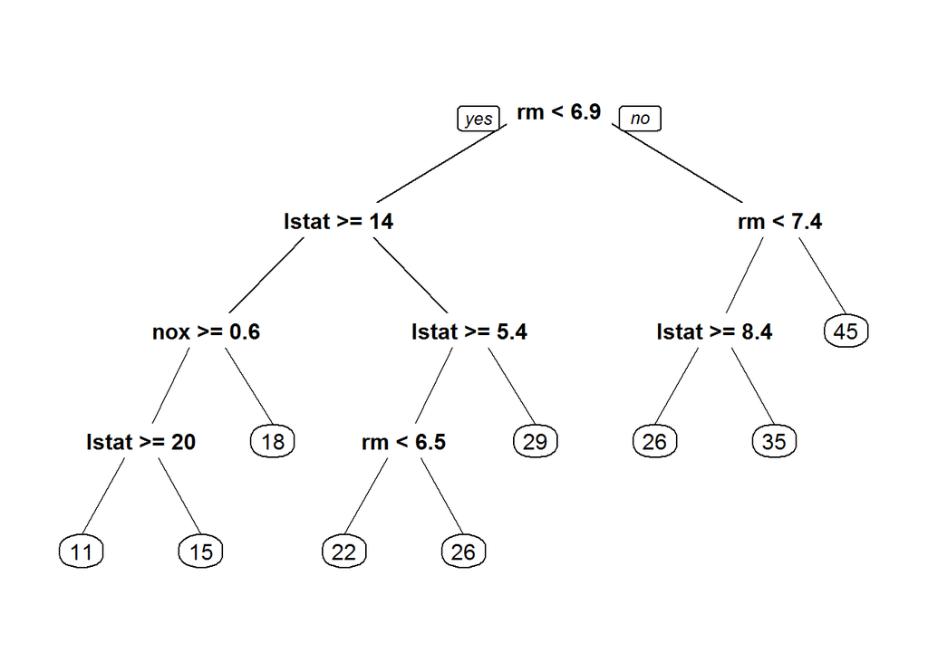

```r
tree <- rpart(medv ~ ., data = train)
prp(tree)
```

The major selling point of the CART trees is their interpretability. In this case, we can see that the room number (`rm`), is the main determining factor in the classification. We also notice that low income status (`lstat`) and nitrous oxide levels (`nox`) contribute to the prices.

The next thing to notice is that some variables appear in the model more than once. This allows us to encode highly non-linear releationships within the data.

For each new data point, we will follow from the root (top) of the tree, and decide if our new sample satisfies the requirements on each node. This essentially introduces a set of `and` predicates for each new sample.

# Predictive ability

Let’s evaluate the predictive ability of the model by calculating the sum of squared errors:

```r
pred <- predict(tree, test)
sum((pred - test$medv)^2)
```

```
## [1] 3931.328
```

# Parameter tuning

We can force the complexity of the tree by changing the number of element each split should classify. The complexity parameter `cp` is inversely proportional to the number of splits we make. `cp` of 1 will result in no splits - all the data will be regressed to a single mean. `cp` of 0 will result in a very large number of splits. See `?rpart.control` for more details.

Let’s make a more detailed classifier, with `cp` of 0.001.

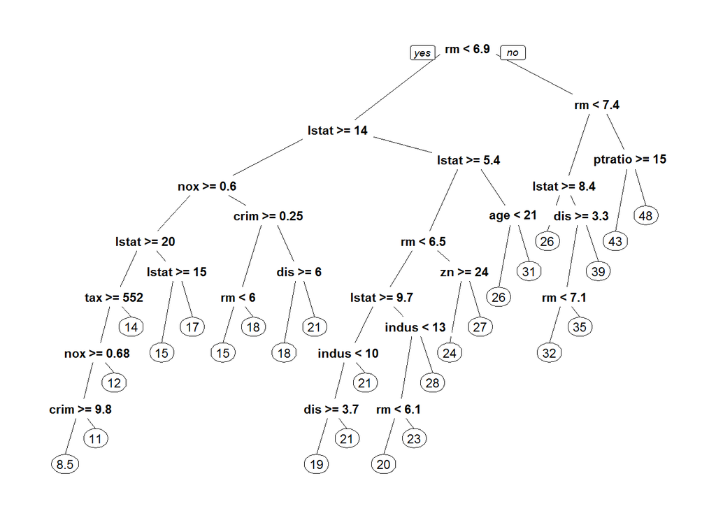

```r
treeComplex <- rpart(medv ~ ., data = train, cp = 0.001)
prp(treeComplex)
```

```r
predComplex <- predict(treeComplex, test)
sum((predComplex - test$medv)^2)
```

```
## [1] 3386.714
```

We can see a small improvement in sum of squared errors. We can try to maximize the fit of the model with the `cp` parameter with cross-validation. However, it will not be touched here.

# Random forests

The random forest algorithm essentially creates multiple regression trees and stochastically chooses the best one. The package `randomForest` does what we want.

```r
library(randomForest)
forest <- randomForest(medv ~ ., data = train, ntree = 200)
```

Since random forest is an ensemble classifier, we can not plot a single representative tree. We can, however, calculate the `SSE` as we did brefore.

```r
predForest <- predict(forest, test)
sum((predForest-test$medv)^2)
```

```
## [1] 1922.897
```

We should see a large improvement in accuracy here.

For more details, consult chapter 8 of [Introduction to Statistical Learning](http://www-bcf.usc.edu/~gareth/ISL/).